# Read counts summary

27 Oct 2020

From the initial taxonomy and feature table data frames, I want to summarize how many reads were on-target (assigned to reference taxa in our custom db) per locus and slim the feature table df down to just the ASVs that have taxonomy assigned for the data decontamination steps and analysis of extraction blanks and negative controls.

```r
library(tidyverse)
library(stringi)
library(readxl)

# feature table df
feature_df_no_eDNA <- readRDS("../data/feature_df_no_eDNA.rds")

# taxonomy table df
#taxonomy_df <- readRDS("../data/fixed_db_taxonomy_df_loci_collapsed.rds")

# metadata
meta <- read_csv("../data/jan_sample_list.csv")
# new taxonomy... probably need to check this.
uncollapsed_taxonomy_spp_98 <- read_rds("../data/uncollapsed_taxonomy_spp_98.rds")
unique_taxonomy_spp_98 <- read_rds("../data/unique_taxonomy_spp_98.rds")

# the four loci
four_loc <- c("mifish", "nsCOIFo", "fishminiA", "cep")

# read in the species and proportions
mock_spp <- read_csv("../data/mock_spp_pool.csv")
```

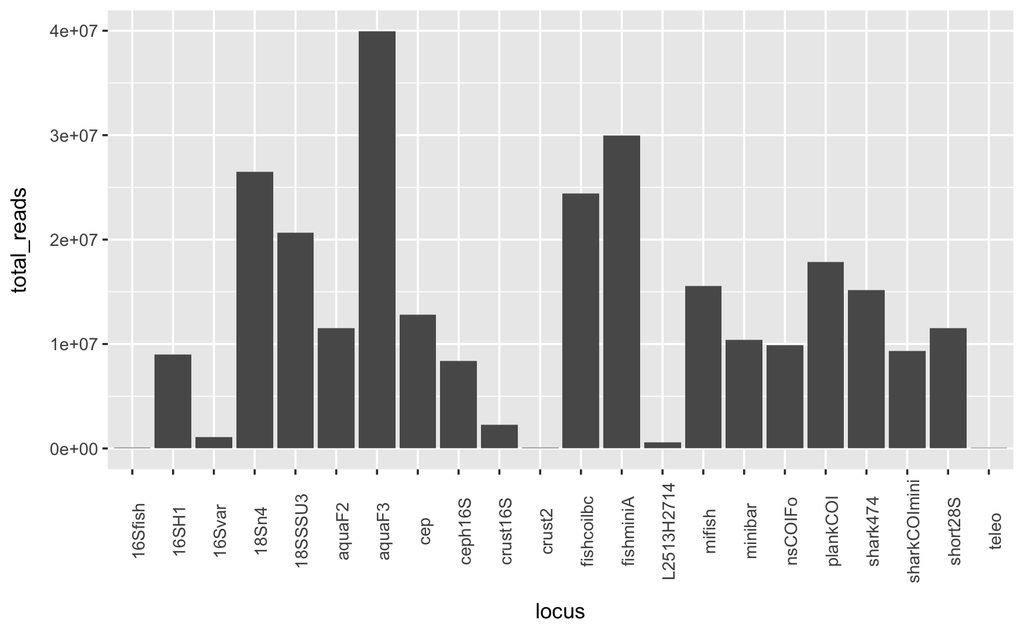

```r
feature_df_no_eDNA %>%
  #filter(str_detect(sample, "RP")) %>% # how many reads per locus in just the reference pools?
  group_by(locus) %>%
  summarise(total_reads = sum(count)) %>%
  ggplot(aes(x = locus, y = total_reads)) +
  geom_bar(stat = "identity", position = "dodge") +
  theme(
  axis.text.x = element_text(angle = 90),
  axis.title.x = element_text(margin = margin(t = 10)),
  axis.title.y = element_text(margin = margin(r = 10))

  )
```

```r
NA
```

```r
# total merged, paired-end reads from dada2
sum_no_eDNA <- feature_df_no_eDNA %>%
  summarise(sum(count))

# and how many unique ASVs?
feature_df_no_eDNA %>%
  select(locus, seq) %>%
  unique()
```

| locus | seq |
| --- | --- |
| 16SH1 | 1c54522245f45b507d2e15930c6b1d98 |
| 16SH1 | 3972212f36dba0c482842c77bdb5bebb |
| 16SH1 | 090c9333d1360c4da723ace4c06ded92 |
| 16SH1 | 5fef0ca77219657fa584b5a4aacdf439 |
| 16SH1 | 72c86d569c953bb2ae458c92e9e5ae19 |
| 16SH1 | aa23ced854060a08a85adea5132ea2ba |
| 16SH1 | 27b032436045b103545f81a5536a005a |
| 16SH1 | 0377ddb40f42a0e21c96e6d1679df004 |
| 16SH1 | fadf5df8afe6ddf7ca80adb6e72d16e8 |
| 16SH1 | 16f9e9511cbd2cc6d326028ddc835bc8 |

[output cut: 990 more lines]

277,021,343 total reads 62,764 unique locus-ASVs

Now bind that together with the taxonomy df so that only those ASVs that are metazoa are retained.

```r
features_w_taxonomy <- feature_df_no_eDNA %>%
  semi_join(., taxonomy_df, by = c("locus", "seq"))
# use a semi_join here to avoid including duplicate rows of the feature table for each taxonomy entry since there are duplicates for each locus-ASV at this stage

# how many reads/ASV

features_w_taxonomy %>%
  summarise(sum(count))
```

| sum(count) |
| --- |
| 244444202 |

244,444,202 total reads (out of 277,021,343) Which is pretty good for a conversion!

```r
244444202/277021343
```

```
[1] 0.8824021
```

88.2% of total reads match taxa in our custom db

How many ASVs?

```r
features_w_taxonomy %>%
  select(locus, seq) %>%
  unique()
```

| locus | seq |
| --- | --- |
| 16SH1 | 1c54522245f45b507d2e15930c6b1d98 |
| 16SH1 | 3972212f36dba0c482842c77bdb5bebb |
| 16SH1 | 090c9333d1360c4da723ace4c06ded92 |
| 16SH1 | 5fef0ca77219657fa584b5a4aacdf439 |
| 16SH1 | 72c86d569c953bb2ae458c92e9e5ae19 |
| 16SH1 | aa23ced854060a08a85adea5132ea2ba |
| 16SH1 | 27b032436045b103545f81a5536a005a |
| 16SH1 | 0377ddb40f42a0e21c96e6d1679df004 |
| 16Svar | 5c8dbcd453adf89ab7b3e769fd6110ee |
| 18SSSU3 | 25aae703dc48c75a628cec9d33f446ef |

[output cut: 990 more lines]

12,792 ASVs retained (out of 62,764)

```r
12792/62764
```

```
[1] 0.2038111
```

Which is only ~20.4% of ASVs… this is where the small number of reads for a large number of non-target ASVs comes into play.

What % of reads matched taxa in the metazoan database?

```r
feature_df_no_eDNA %>%
  left_join(., unique_taxonomy_spp_98) %>%
  mutate(grp = ifelse(is.na(taxon), "non-metazoan", "metazoan")) %>%
  group_by(grp) %>%
  summarise(reads = sum(count)) %>%
  mutate(total_reads = sum(reads)) %>%
  mutate(prop_reads = reads/total_reads)
```

| grp | reads | total_reads | prop_reads |
| --- | --- | --- | --- |
| metazoan | 244290311 | 277021343 | 0.8818465 |
| non-metazoan | 32731032 | 277021343 | 0.1181535 |

```r
# understanding the composition of blanks and controls
feature_df_no_eDNA %>%
  #left_join(., unique_taxonomy_spp_98) %>%
  filter(str_detect(sample, "EXB") | str_detect(sample, "NEG")) %>%
  #mutate(grp = ifelse(is.na(taxon), "non-metazoan", "metazoan")) %>%
  #filter(grp == "non-metazoan") %>%
  select(locus, seq) %>% # NEED to include the locus here
  unique()
```

| locus | seq |
| --- | --- |
| 16SH1 | 1c54522245f45b507d2e15930c6b1d98 |
| 16SH1 | 3972212f36dba0c482842c77bdb5bebb |
| 16SH1 | 090c9333d1360c4da723ace4c06ded92 |
| 16SH1 | 5fef0ca77219657fa584b5a4aacdf439 |
| 16SH1 | 72c86d569c953bb2ae458c92e9e5ae19 |
| 16SH1 | aa23ced854060a08a85adea5132ea2ba |
| 16SH1 | 27b032436045b103545f81a5536a005a |
| 16SH1 | 0377ddb40f42a0e21c96e6d1679df004 |
| 16SH1 | fadf5df8afe6ddf7ca80adb6e72d16e8 |
| 16SH1 | 16f9e9511cbd2cc6d326028ddc835bc8 |

[output cut: 990 more lines]

```r
NA
```

total of 2,144 ASVs in the blanks and controls

And how many of the unassigned ASVs were found only in the blanks and controls?

```r
not_blanks <- feature_df_no_eDNA %>%
  left_join(., unique_taxonomy_spp_98) %>%
  filter(!str_detect(sample, "EXB") & !str_detect(sample, "NEG")) %>%
  mutate(grp = ifelse(is.na(taxon), "non-metazoan", "metazoan")) %>%
  filter(grp == "non-metazoan") %>%
  select(locus, seq) %>% # NEED to include the locus here
  unique()
only_in_blanks <- feature_df_no_eDNA %>%
  left_join(., unique_taxonomy_spp_98) %>%
  filter(str_detect(sample, "EXB") | str_detect(sample, "NEG")) %>%
  mutate(grp = ifelse(is.na(taxon), "non-metazoan", "metazoan")) %>%
  filter(grp == "non-metazoan") %>%
  select(locus, seq, sample) %>% # NEED to include the locus here
  unique()
only_in_blanks %>%
  right_join(., not_blanks) %>%
  filter(!is.na(sample))
```

| locus | seq | sample |
| --- | --- | --- |
| aquaF3 | 4c1fc5ca17b0f928f24e2bdcaa621305 | EXB3 |
| aquaF3 | 2d4bd32116005fa473d76fd6942a6c85 | EXB3 |
| fishcoilbc | 2bb7cdf453f4dbdd0d3cdea320fa9282 | EXB3 |
| fishminiA | 3fc137e227f7ad8506d040a6832c85a3 | EXB1 |
| fishminiA | 58d4fba86af3a9a55e7dbc10cb277ac3 | EXB1 |
| fishminiA | 58d4fba86af3a9a55e7dbc10cb277ac3 | EXB3 |
| minibar | afb6c410072c0e4d0855782aa3277b34 | EXB1 |
| minibar | 2bb7cdf453f4dbdd0d3cdea320fa9282 | EXB3 |
| nsCOIFo | 03993a6b1e179ea6cf6f9e1b80bd5d74 | EXB1 |
| nsCOIFo | bd8de9ff4d5ee174aee65d771feece86 | EXB2 |

[output cut: 85 more lines]

95 locus-ASVs are in both extraction blanks and samples.

1824-95 # unique to blanks

```
[1] 1729
```

```
[1] 0.03459938
```

What % of the blanks ASVs are non-metazoan?

```
[1] 0.8507463
```

What % of the reads didn’t match metazaon?

```r
feature_df_no_eDNA %>%
  left_join(., unique_taxonomy_spp_98) %>%
  filter(str_detect(sample, "EXB") | str_detect(sample, "NEG")) %>%
  mutate(grp = ifelse(is.na(taxon), "non-metazoan", "metazoan")) %>%
  group_by(grp) %>%
  summarise(reads = sum(count)) %>%
  mutate(total_reads = sum(reads)) %>%
  mutate(prop_reads = reads/total_reads)
```

| grp | reads | total_reads | prop_reads |
| --- | --- | --- | --- |
| metazoan | 1912703 | 2724545 | 0.7020266 |
| non-metazoan | 811842 | 2724545 | 0.2979734 |

### Negative controls

It seems like the logical path forward is to report the negatives, but not to remove taxa because the negatives across samples are not consistent and it’s better not to introduce a bias in that respect.

Also important here to acknowledge that the lab work was not performed in a clean lab and that extraction blanks and PCR negatives were sequenced with equal depth to the other samples (so read counts are artificially higher for the small number of molecules that were likely inputs).

I could imagine a plot like that in supplemental - to indicate that the overall read counts were very low comparably for the extraction blanks and negative controls.

What I really want to highlight are the reads that have: 1) taxonomic info 2) reference taxa 3) Gallus/Sus sp.

Mock feed species

```r
# create a vector of those spp
m.species <- mock_spp$species
m.genera <- mock_spp$genus
m.family <- mock_spp$family
```

Question: do the feeds with F2 consistently have a larger proportion of “other metazoan” reads?

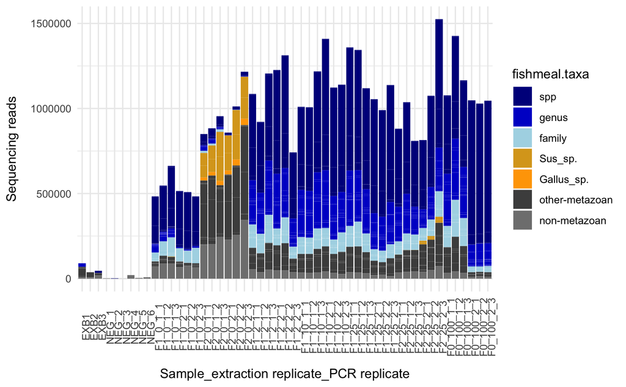

```r
# beginning with a df with just the feeds and controls
# one entry per sequence
# including only the porfolio of four primer sets
feed_reads_replot <- feature_df_no_eDNA %>%
  filter(!str_detect(sample, "RP")) %>% # remove the reference pools
  filter(!str_detect(sample, "MEP") & !str_detect(sample, "MFP")) %>% # remove the mock pools
  left_join(., unique_taxonomy_spp_98) %>% # add the taxonomy to relevant entries
  filter(locus %in% c(four_loc)) %>% # include just the portfolio of four loci
  left_join(., meta) %>% # add the meta data with new feed names
  mutate(sample = ifelse(str_detect(sample, "F"), new_name, sample)) %>% # use the "new names" for the feed samples bec they have consistent syntax
  mutate(fishmeal.taxa = ifelse(taxon %in% c(m.species), "spp", NA)) %>%
  mutate(fishmeal.taxa = ifelse(taxon %in% c(m.genera), "genus", fishmeal.taxa)) %>%
  mutate(fishmeal.taxa = ifelse(taxon %in% c(m.family), "family", fishmeal.taxa)) %>%
  #mutate(metazoan = ifelse(is.na(taxon), "no", "yes")) %>%
  mutate(fishmeal.taxa = ifelse(str_detect(taxon, "Sus"), "Sus_sp.", fishmeal.taxa)) %>%
  mutate(fishmeal.taxa = ifelse(str_detect(taxon, "Gallus"), "Gallus_sp.", fishmeal.taxa)) %>%
  mutate(fishmeal.taxa = ifelse(is.na(taxon), "non-metazoan", fishmeal.taxa)) %>%
  mutate(fishmeal.taxa = ifelse(is.na(fishmeal.taxa), "other-metazoan", fishmeal.taxa)) %>%
  group_by(sample, taxon, fishmeal.taxa) %>%
  summarise(total_reads = sum(count)) %>%
  # add back in the % fishmeal to get the order right
  left_join(., meta, by = c("sample" = "new_name")) %>%
  #mutate(perc_fishmeal = ifelse(str_detect(sample, "F0"), 100, perc_fishmeal)) %>% # this needs to be made explicit bec of the new sample name
  mutate(perc_fishmeal = ifelse(is.na(perc_fishmeal), -1, perc_fishmeal)) %>%
  arrange(perc_fishmeal)
# manually set the factor levels for the taxa legend
feed_reads_replot$fishmeal.taxa <- factor(feed_reads_replot$fishmeal.taxa, levels = c("spp", "genus", "family", "Sus_sp.", "Gallus_sp.", "other-metazoan", "non-metazoan"))


# plot that with all the factors in order
feed_reads_replot %>%
  ggplot(aes(x = reorder(sample, perc_fishmeal), y = total_reads, fill = fishmeal.taxa)) +
  geom_bar(stat = "identity", position = "stack") +
  theme_minimal() +
  xlab("Sample_extraction replicate_PCR replicate") +
  ylab("Sequencing reads") +
  scale_fill_manual(values = c("darkblue", "mediumblue", "lightblue", "goldenrod", "orange", "gray30", "gray50")) +
  theme(
  axis.text.x = element_text(angle = 90),
  axis.title.x = element_text(margin = margin(t = 10)),
  axis.title.y = element_text(margin = margin(r = 10))
)
```

```r
NA
```

And now the question is one of proportions: in the 0% fishmeal samples, what proportion of the sequencing reads are going to Sus and Gallus?

| filler | mean_prop_fish_reads |
| --- | --- |
| F1 | 0.79880232 |
| F2 | 0.06773414 |

And what about the mean non-fish reads for filler 1 and filler 2?

| filler | mean_prop_filler2_reads |
| --- | --- |
| F1 | 0.0016431 |
| F2 | 0.2570551 |

Compare that with Filler 2 and 25% fishmeal

| filler | mean_prop_filler2_reads |
| --- | --- |
| F2 | 0.01127108 |

### Read counts per primer set: negative controls and blanks

Just read counts for the negatives and extraction blanks

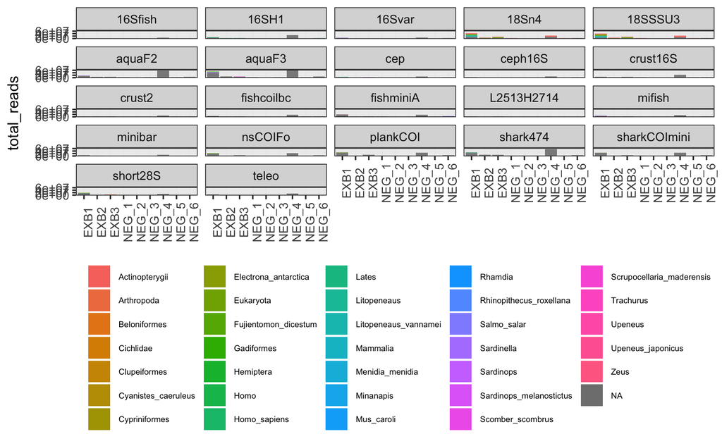

```r
# all loci
neg_blanks <- feature_df_no_eDNA %>%
  left_join(., meta) %>%
  filter(type %in% c("blank", "negative")) %>%
  left_join(., unique_taxonomy_spp_98) %>%
  #mutate(taxon = ifelse(is.na(taxon), "non metazoan", taxon)) %>%
  group_by(sample) %>%
  mutate(total_reads = sum(count)) %>%
  ungroup() %>%
  group_by(locus) %>%
  mutate(loc_reads = sum(count)) %>%
  ggplot(aes(x = sample, y = total_reads, fill = taxon)) +
  geom_bar(stat = "identity") +
  facet_wrap(~locus) +
  theme_bw()
neg_blanks +
  theme(
  axis.text.x = element_text(angle = 90),
  axis.title.x = element_blank(),
  axis.title.y = element_text(margin = margin(r = 10)),
  legend.position = "bottom",
  legend.title = element_blank(),
  legend.text = element_text(size = 6)
)
```

## read summary for reference pools

```r
feature_df_no_eDNA %>%
  filter(str_detect(sample, "RP") | str_detect(sample, "EX") | str_detect(sample, "NEG")) %>% # just the reference pools
  left_join(., unique_taxonomy_spp_98) %>% # add the taxonomy to relevant entries
  mutate(ord = ifelse(str_detect(sample, "EX"), 1, 3)) %>%
    mutate(ord = ifelse(str_detect(sample, "NEG"), 2, ord)) %>%
  mutate(reads = ifelse(is.na(taxon), NA, "metazoa"))
```

| locus | seq | sample | count | taxon | taxonomic_level | top_perc_id | ord | reads |
| --- | --- | --- | --- | --- | --- | --- | --- | --- |
| 16SH1 | 1c54522245f45b507d2e15930c6b1d98 | EXB1 | 592 | Homo_sapiens | species | 99.524 | 1 | metazoa |
| 16SH1 | 3972212f36dba0c482842c77bdb5bebb | EXB1 | 600 | Homo_sapiens | species | 100.000 | 1 | metazoa |
| 16SH1 | 090c9333d1360c4da723ace4c06ded92 | EXB1 | 572 | Homo_sapiens | species | 99.528 | 1 | metazoa |
| 16SH1 | 5fef0ca77219657fa584b5a4aacdf439 | EXB1 | 620 | Homo_sapiens | species | 99.524 | 1 | metazoa |
| 16SH1 | 72c86d569c953bb2ae458c92e9e5ae19 | EXB1 | 618 | Homo_sapiens | species | 100.000 | 1 | metazoa |
| 16SH1 | aa23ced854060a08a85adea5132ea2ba | EXB1 | 596 | Homo_sapiens | species | 100.000 | 1 | metazoa |
| 16SH1 | 27b032436045b103545f81a5536a005a | EXB1 | 528 | Homo_sapiens | species | 99.531 | 1 | metazoa |
| 16SH1 | 0377ddb40f42a0e21c96e6d1679df004 | EXB1 | 545 | Homo_sapiens | species | 99.528 | 1 | metazoa |
| 16SH1 | fadf5df8afe6ddf7ca80adb6e72d16e8 | EXB1 | 67 | NA | NA | NA | 1 | NA |
| 16SH1 | 16f9e9511cbd2cc6d326028ddc835bc8 | EXB1 | 59 | NA | NA | NA | 1 | NA |

[output cut: 990 more lines]

Also could use a boxplot to show the mean…

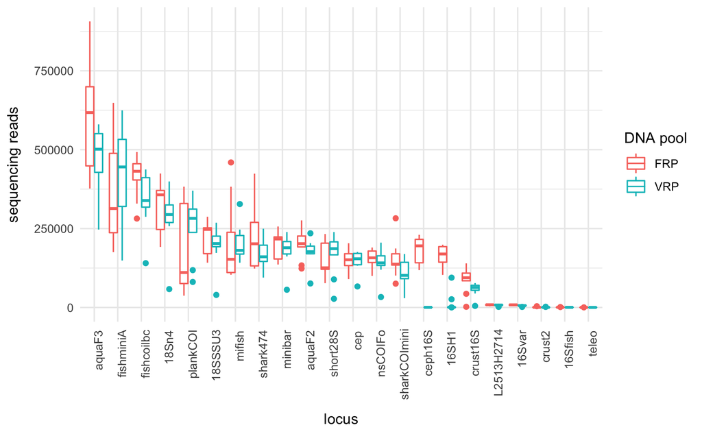

And to confirm, the summary distribution for reads/locus:

```r
feature_df_no_eDNA %>%
  filter(str_detect(sample, "RP")) %>% # just the reference pools
  group_by(locus, sample) %>%
  mutate(cum_reads = sum(count)) %>%
  select(locus, cum_reads) %>%
  unique() %>%
  arrange(desc(cum_reads))
```

| sample | locus | cum_reads |
| --- | --- | --- |
| FRP_1_2 | aquaF3 | 906477 |
| FRP_2_1 | aquaF3 | 815630 |
| FRP_2_2 | aquaF3 | 699462 |
| FRP_1_3 | aquaF3 | 662975 |
| FRP_1_2 | fishminiA | 648456 |
| FRP_2_1 | fishminiA | 630543 |
| VRP_3_3 | fishminiA | 624500 |
| FRP_3_2 | aquaF3 | 617660 |
| VRP_1_3 | aquaF3 | 580351 |
| FRP_2_3 | aquaF3 | 562765 |

[output cut: 386 more lines]

## ASVs found only in the extraction blanks and negatives (and not in the samples?)

# total number of taxonomically assigned ASVs in the controls?

| locus | seq |
| --- | --- |
| 18SSSU3 | 4de334efe9d0d3e42a3864ec4fff793b |
| 18SSSU3 | d0eba77310335fc5842c9b2e67870fca |
| 18SSSU3 | 32d4fcafeefb638fe168702df16082c1 |
| 18SSSU3 | cfabcf837654a416bf59cb966480243d |
| 18SSSU3 | 1a5c64f6431204b980504f043c9be9da |
| 18SSSU3 | de6d960dc0def5a6c06222fb57982219 |
| 18SSSU3 | d701b657dfeb0541584b97708bff6eed |
| 18SSSU3 | c88d451b72e3781e8d71e4a597321f51 |
| 18SSSU3 | dfe1f64d05e852adcc47db5cf7bebbf4 |
| 18SSSU3 | 3e873fd8cd71ce8b1ca54123fdfe0b38 |

[output cut: 179 more lines]

334 ASVs in the negatives and blanks and 189 of those ASVs are only found in the controls.

## Save the feature table for subsequent analyses

I’ll use this dataframe for the occupancy modeling followed by the dissimilarity matricies.